# Function Tutorial

Gabriela Rosario

2023-07-12

These tutorials were made for a data science class. I chose these functions as I wanted to learn skills that could be useful in the field of neuroscience, which is one of my primary interests. While the examples used for image_animate and sub_str are not used with the main focus of neuroscience, the functions can be of great benefit in the field. Some examples of the work that can be done include creating gifs presenting a 3D rotation of the brain and extracting DNA sequence from a specific start and end position.

### read.fs.volume

#### **read.fs.volume**

`read.fs.volume` is a function within the `freesurferformats` package, which contains a series of functions that are designed to read and process MRI data that is normally viewed on the *Freesurfer* software.

The `read.fs.volume` function is used to read a volume file from FreeSurfer into an R object. It takes the path to the volume file as an input and returns an object, specifically an array, representing the volume data (in mm<sup>3</sup>). This is useful as brain volume is one of the main forms of measuring and determining brain size.

**Basic Syntax:** `read.fs.volume(volume_file)`

`volume_file`: The function uses MGH (named after *Massachusetts General Hospital*) and MGZ (gzipped version of MGH) files. They often provide 3D images of brain MRI scans, or morphometry data for brain surfaces, built up in units called voxels. Each voxel represents about million brain cells.

**Example:**

```r
# load package
library(freesurferformats)

# load example brain data
example_brain <- system.file("extdata", "brain.mgz", package = "freesurferformats", mustWork = TRUE);

# read the volume from file
brain_volume <- read.fs.volume(example_brain)

# you can also upload mgz or mgh files directly from your repository folder by using 'read.fs.volume("file_name")

# check structure of 'brain_volume'
str(brain_volume)
```

```
##  int [1:256, 1:256, 1:256, 1] 0 0 0 0 0 0 0 0 0 0 ...
```

```r
# using this data, you can perform operations or analysis on brain volume

# calculate the minimum volume per voxel
min(brain_volume)
```

```
## [1] 0
```

```r
# calculate the maximum volume per voxel
max(brain_volume)
```

```
## [1] 156
```

```r
# calculate the mean volume per voxel
mean(brain_volume)
```

```
## [1] 7.214277
```

### image_animate

#### **image_animate**

The `image_animate` function is a part of the `magick` package in R. It is used to create GIFs by animating sequences of individual images.

**Basic Syntax:** `image_animate(image, fps = 10, dispose = "previous")`

`image`: A sequence of individual image objects. This can be done using assigning multiple images to one object using `image_read` and concatenation (`c("image_file1","image_file2",...)`), or assigning each image to their own object and then assigning all the objects to a vector using concatenation.

`fps`: Frames per second (i.e the speed of the animation). The default value is 10.

`dispose`: Specifies the method used for disposing of the previous frame before rendering the next frame. The default value is “previous”, which means each frame replaces the previous frame.

**Example:**

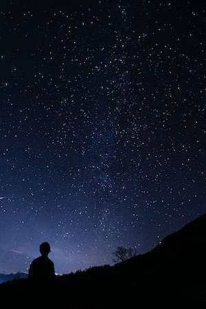

```r
# load package
library(magick)

# Read images from URL and assign them to an object
total_images <- image_read(c("https://images.unsplash.com/photo-1516571748831-5d81767b788d?ixlib=rb-4.0.3&q=85&fm=jpg&crop=entropy&cs=srgb&dl=klemen-vrankar-lcT_p8kLCsc-unsplash.jpg&w=300", "https://images.unsplash.com/photo-1559571416-d11cec5fc4dc?ixlib=rb-4.0.3&q=85&fm=jpg&crop=entropy&cs=srgb&dl=jose-maria-garcia-garcia-eU--lob11iw-unsplash.jpg&w=300","https://images.unsplash.com/photo-1576806157689-f8fa4f3a82fd?ixlib=rb-4.0.3&q=85&fm=jpg&crop=entropy&cs=srgb&dl=bradley-allweil-3jGU345xw2w-unsplash.jpg&w=300", "https://images.unsplash.com/photo-1435224654926-ecc9f7fa028c?ixlib=rb-4.0.3&q=85&fm=jpg&crop=entropy&cs=srgb&dl=wil-stewart-T26KCgCPsCI-unsplash.jpg&w=300", "https://images.unsplash.com/photo-1547501344-5301c9fb9edf?ixlib=rb-4.0.3&q=85&fm=jpg&crop=entropy&cs=srgb&dl=nikolay-hristov-qTN7y0IyG4w-unsplash.jpg&w=300", "https://images.unsplash.com/photo-1557162629-292e018d65ff?ixlib=rb-4.0.3&q=85&fm=jpg&crop=entropy&cs=srgb&dl=zhanjiang-chen-2TWVY8WkzNY-unsplash.jpg&w=300"))

# You can also upload images directly from your repository folder by using 'image_read("file_name")'

# Create an animated image using image_animate from the magick package
animated_gif <- image_animate(total_images, fps = 4)

# load finished gif
animated_gif
```

**All images were obtained through the open source website: [www.unsplash.com](https://unsplash.com/)**

### str_sub

#### **str_sub**

`str_sub` is a function in the `stringr` package that extracts substrings from character vectors based on specific start and end positions. This is useful as it can be used to either extract the characters present in the data or to manipulate the data.

**Basic Syntax:** `str_sub(string, start, end)`

`string`: The character vector/object where substrings will be extracted from

`start`: The starting position of the substring. It can be a numeric value, a vector of numeric values, or a single integer specifying the starting position.

`end`: The ending position(s) of the substring(s). It can be a numeric value, a vector of numeric values, or a single integer specifying the ending position.

**Example:**

```r
# load package
library(stringr)

# create a string and assign it to an object
greeting <- "Hi There!"

# extract a substring using start and end positions
shortened_greeting <- str_sub(greeting, start = 1, end = 2)
print(shortened_greeting)
```

```
## [1] "Hi"
```

```r
# extract a substring using negative start and end positions
shortened_greeting2 <- str_sub(greeting, start = -6, end = -2)
print(shortened_greeting2)
```

```
## [1] "There"
```